# Analyzing SeaAroundUs Fishing Catch Composition in Large Marine Ecosystems (1950-2019)

The Scotian Shelf LME

Jorge Mestre Tomás

2024-07-26

```r
# Load libraries
library(compositions)
library(INLA)
library(INLAcomp)
library(tidyverse)
```

```r
# Set seed
set.seed(475908)
inla.seed <- sample.int(n = 1E6, size = 1)
```

# Data loading

Load compositional data.

```r
single_lme <- read.table("data/clean_data/lme_comp.csv", header = TRUE, sep = "\t", dec = ".") %>%
  filter(area_id == 8) %>%
  select(!tonnes) %>%
  pivot_wider(names_from = functional_group, values_from = comp)
```

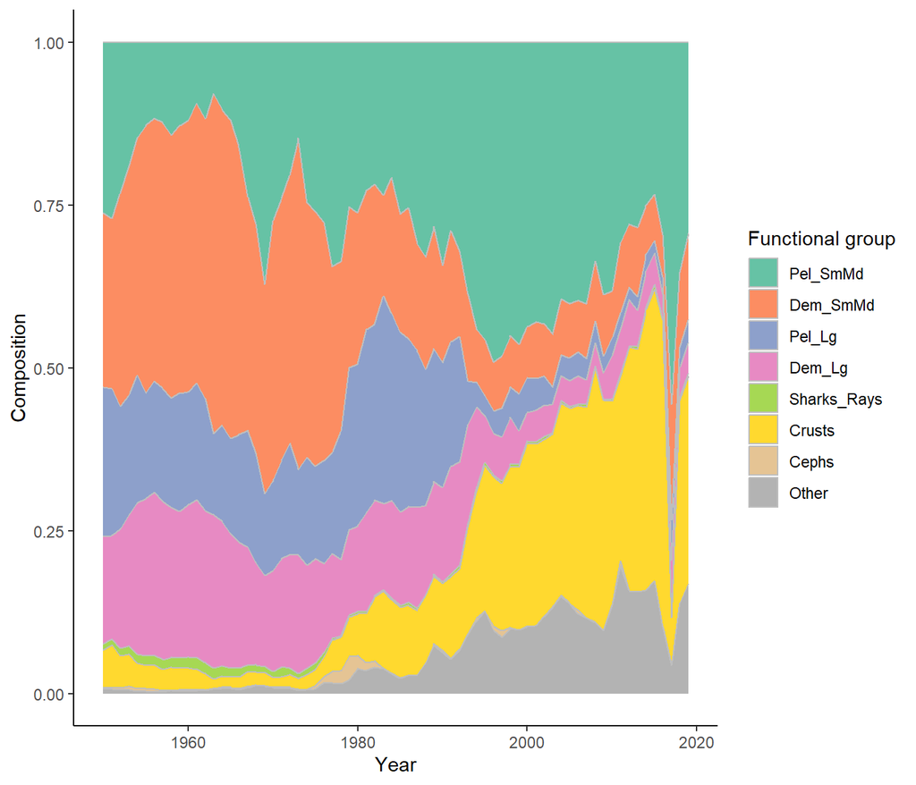

# Data preparation for fitting

```r
# Composition
y <- acomp(single_lme[, func_grp_lvls]) %>%
  as.data.frame()
head(y)
```

|  | Pel_SmMd | Dem_SmMd | Pel_Lg | Dem_Lg | Sharks_Rays | Crusts | Cephs | Other |
| --- | --- | --- | --- | --- | --- | --- | --- | --- |
| 1 | 0.2625094 | 0.2665724 | 0.2299708 | 0.1644206 | 0.009848279 | 0.05721222 | 0.001960386 | 0.007505888 |
| 2 | 0.2700883 | 0.2612687 | 0.2256462 | 0.1593642 | 0.008757086 | 0.06535339 | 0.002740618 | 0.006781480 |
| 3 | 0.2310468 | 0.3281226 | 0.1879426 | 0.1828553 | 0.011446568 | 0.04962921 | 0.002970119 | 0.005986757 |
| 4 | 0.1896571 | 0.3519067 | 0.1839160 | 0.2015751 | 0.012621749 | 0.04903129 | 0.005215787 | 0.006076313 |
| 5 | 0.1466063 | 0.3644515 | 0.1958688 | 0.2327231 | 0.013479701 | 0.03857896 | 0.004574192 | 0.003717519 |
| 6 | 0.1276045 | 0.4111455 | 0.1616555 | 0.2411765 | 0.014642918 | 0.03634110 | 0.003423319 | 0.004010703 |

## Transformation to *alr*-coordinates

We will choose as reference category for the `alr` transformation the one with lowest variance (one with low variability) and also that doesn’t have a very small value.

```r
sort(apply(y, 2, function(x){var(log(x))}))
```

```
##    Pel_SmMd      Dem_Lg    Dem_SmMd Sharks_Rays      Pel_Lg      Crusts
##   0.2106215   0.3871880   0.4678774   0.6065604   0.7735129   1.2173731
##       Other       Cephs
##   1.8691419   1.9451750
```

```r
sort(mean(acomp(y)), decreasing = T)
```

```
##      Pel_SmMd      Dem_SmMd        Dem_Lg        Pel_Lg        Crusts
## "0.333603033" "0.241778822" "0.142327594" "0.124645256" "0.112382145"
##         Other   Sharks_Rays         Cephs
## "0.036815730" "0.006786065" "0.001661355"
## attr(,"class")
## [1] "acomp"
```

In this case we compute $alr$-coordinates using `Other` as reference category.

```r
y <- y[,c("Pel_SmMd", "Dem_SmMd", "Pel_Lg", "Dem_Lg",
          "Sharks_Rays", "Crusts", "Cephs", "Other")]
data <- alr(y) %>% as.data.frame()
head(data)
```

|  | Pel_SmMd | Dem_SmMd | Pel_Lg | Dem_Lg | Sharks_Rays | Crusts | Cephs |
| --- | --- | --- | --- | --- | --- | --- | --- |
| 1 | 3.554599 | 3.569958 | 3.422265 | 3.086740 | 0.2716090 | 2.031080 | -1.3425463 |
| 2 | 3.684554 | 3.651354 | 3.504773 | 3.156997 | 0.2556678 | 2.265614 | -0.9060118 |
| 3 | 3.653070 | 4.003838 | 3.446587 | 3.419145 | 0.6481401 | 2.115030 | -0.7009480 |
| 4 | 3.440819 | 4.058968 | 3.410081 | 3.501764 | 0.7310233 | 2.088061 | -0.1527082 |
| 5 | 3.674694 | 4.585337 | 3.964388 | 4.136793 | 1.2881284 | 2.339651 | 0.2073735 |
| 6 | 3.459969 | 4.629980 | 3.696501 | 4.096562 | 1.2949902 | 2.203983 | -0.1583560 |

```r
D <- k <- ncol(y)
N <- nrow(y)
names_y <- colnames(y)
names_alry <- colnames(data)
```

## Include time

Starting from 1.

```r
data$time <- 1:nrow(data)
```

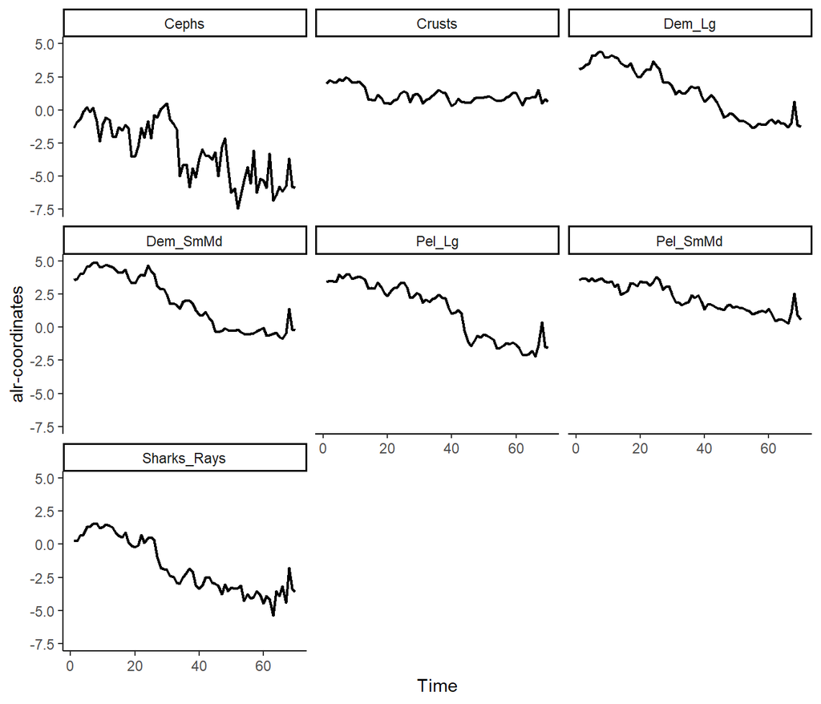

## Extending the dataset

Extend the dataset of the $alr$-coordinates to fit in the `inla.stack`.

```r
data_ext <- data %>%
  tidyr::pivot_longer(., cols = names_alry,
                      names_to = "alr_names",
                      values_to = "alr_resp") %>%
  .[order(ordered(.$alr_names)),]
data_ext$alr_names <- ordered(data_ext$alr_names)
head(data_ext)
```

| time | alr_names | alr_resp |
| --- | --- | --- |
| 1 | Cephs | -1.3425463 |
| 2 | Cephs | -0.9060118 |
| 3 | Cephs | -0.7009480 |
| 4 | Cephs | -0.1527082 |
| 5 | Cephs | 0.2073735 |
| 6 | Cephs | -0.1583560 |

## Define index for each alr-coordinate

```r
k_group <- data_ext$alr_names %>% as.numeric() #For group
k_repl  <- data_ext$alr_names %>% as.numeric() #For replication
head(data.frame(k_group, k_repl))
```

|  | k_group | k_repl |
| --- | --- | --- |
| 1 | 1 | 1 |
| 2 | 1 | 1 |
| 3 | 1 | 1 |
| 4 | 1 | 1 |
| 5 | 1 | 1 |
| 6 | 1 | 1 |

## Index for the temporal effects

```r
iset <- inla.spde.make.index('i', n.spde = nrow(data),
                             n.repl  = k-1) #Replicating temporal effect
```

### iset for copy

```r
iset2 <- inla.spde.make.index('i', n.spde = nrow(data))
iset_aux <- matrix(NA, ncol = k-1, nrow = k-1)
diag(iset_aux) <- rep(1, k-1)
iset2 <- kronecker(iset_aux, iset2$i)
colnames(iset2) <- names_alry
```

## Define the part to the shared random effect

```r
# Index for the random effect that is going to give the correlation
id_z <- rep(1:(dim(data_ext)[1]/(k-1)), k-1)

# Index for indicating the alr-coordinate
id_cat <- rep(1:(k-1), rep(N, k-1))
```

## Response variable in R-INLA

Matrix with dimmension $(N \times (D-1)) \times (D - 1)$ for including the multivariate response in R-INLA.

```r
1:length(names_alry) %>%
  lapply(., function(i){
    data_ext %>%
      dplyr::filter(alr_names == names_alry[i]) -> data_comp_i
    #Response
    y_alr <- matrix(ncol = names_alry %>% length(.), nrow = dim(data_comp_i)[1])
    y_alr[, i] <- data_comp_i$alr_resp
  }) -> alr_resp

1:length(names_alry) %>%
  lapply(., function(i){
    y_aux <- data_ext %>%
      dplyr::select(alr_resp, alr_names) %>%
      dplyr::filter(alr_names == names_alry[i]) %>%
      dplyr::select(alr_resp) %>%
      as.matrix(.)
    aux_vec <- rep(NA, (D-1))
    aux_vec[i] <- 1
    kronecker(aux_vec, y_aux)
  }) -> y_list

y_alr <- do.call(cbind, y_list)
y_alr[c(1, 71, 141, 211, 291, 361, 421), ]
```

```
##          [,1]     [,2]     [,3]    [,4]    [,5]     [,6]      [,7]
## [1,] 3.554599       NA       NA      NA      NA       NA        NA
## [2,]       NA 3.569958       NA      NA      NA       NA        NA
## [3,]       NA       NA 3.422265      NA      NA       NA        NA
## [4,]       NA       NA       NA 3.08674      NA       NA        NA
## [5,]       NA       NA       NA      NA 1.47853       NA        NA
## [6,]       NA       NA       NA      NA      NA 2.178134        NA
## [7,]       NA       NA       NA      NA      NA       NA -1.342546
```

## Covariates in R-INLA

Covariates are included in the model as random effects with big variances.

```r
variables <- c("intercept", "time")
id_names <- paste0("id_", variables)
id_variables <- rep(id_cat, length(variables)) %>%
  matrix(., ncol = length(variables), byrow = FALSE)
colnames(id_variables) <- id_names
```

## INLA stack for estimation

```r
stk_est <- inla.stack(
  data    = list(resp = y_alr),
  A       = list(1, 1, 1),
  effects = list(c(iset),
    cbind(data_ext %>% dplyr::select(time),

          id_z,
          id_variables,
          intercept = 1),
    data.frame(iset2)
  ),
  tag     = 'est'
)
```

# Fitting the different models

## Model I

### Fitting the model

Common parameters for the different categories and time as covariate.

```r
formula_modelI <- resp ~ -1 +
  intercept +
  time +
  f(id_z,
    model = "iid",
    constr = TRUE)

modelI <- inla(
  formula_modelI,
  family = rep("gaussian", D - 1),
  data = inla.stack.data(stk_est),
  control.compute = list(config = TRUE,
                         dic = TRUE,
                         waic = TRUE,
                         cpo = TRUE),
  control.predictor = list(A = inla.stack.A(stk_est),
                           compute = TRUE),
  verbose = FALSE
)
```

### Posterior distribution of the fixed effects

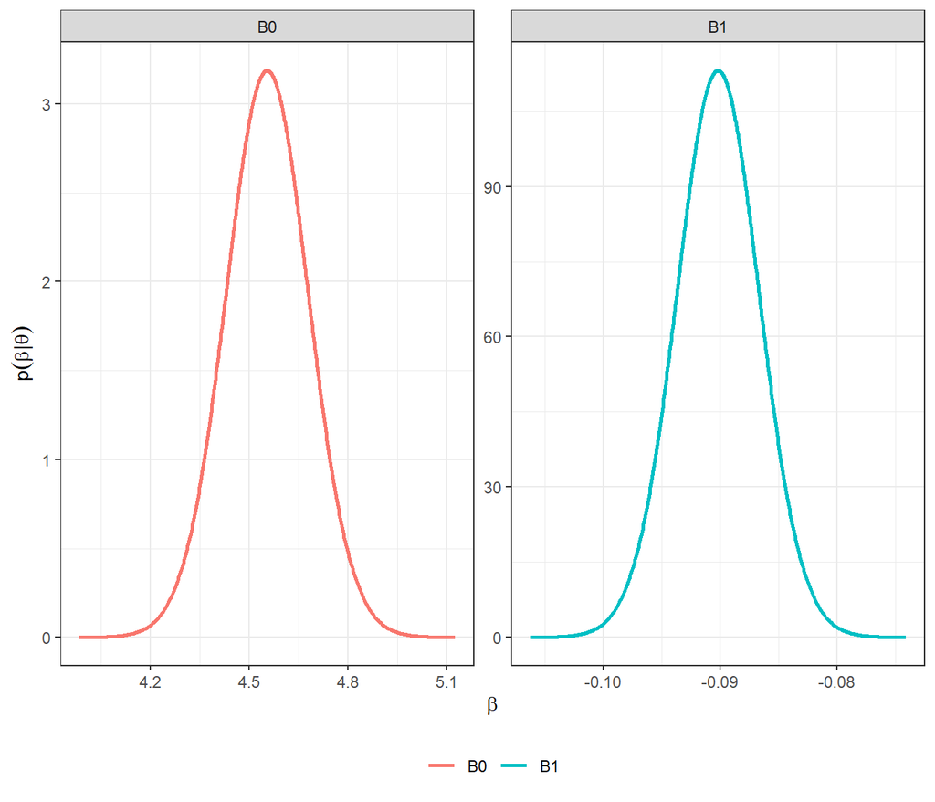

```r
data_betas <- rbind(
  data.frame(inla.smarginal(modelI$marginals.fixed$intercept), var = "B0"),
  data.frame(inla.smarginal(modelI$marginals.fixed$time), var = "B1")
)

ggplot() +
  geom_line(data = data_betas, aes(x = x, y = y, col = var), linewidth = 0.9) +
  facet_wrap(~var, scales = "free") +
  theme_bw() +
  theme(legend.position = "bottom") +
  xlab(expression(beta)) +
  ylab(expression(p(beta *'|'* theta))) +
  theme(legend.title = element_blank())
```

### Posterior distribution of the hyperparameters

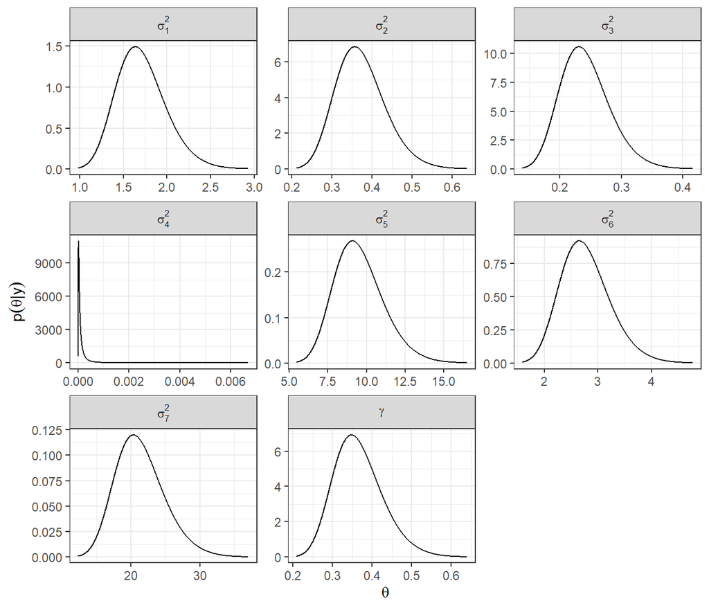

```r
prec <- list(sigma2.1 = modelI$marginals.hyperpar$`Precision for the Gaussian observations`,
             sigma2.2 = modelI$marginals.hyperpar$`Precision for the Gaussian observations[2]`,
             sigma2.3 = modelI$marginals.hyperpar$`Precision for the Gaussian observations[3]`,
             sigma2.4 = modelI$marginals.hyperpar$`Precision for the Gaussian observations[4]`,
             sigma2.5 = modelI$marginals.hyperpar$`Precision for the Gaussian observations[5]`,
             sigma2.6 = modelI$marginals.hyperpar$`Precision for the Gaussian observations[6]`,
             sigma2.7 = modelI$marginals.hyperpar$`Precision for the Gaussian observations[7]`,
             gamma = modelI$marginals.hyper$`Precision for id_z`)

hyper <- lapply(1:length(prec),
                function(x){
                  inla.smarginal(inla.tmarginal(prec[[x]], fun = function(y)(1/y))) %>%
                    data.frame(.)
                })
names(hyper) <- names(prec)

hyper.df <- lapply(1:length(hyper),
                   function(x){
                     cbind(data.frame(hyper[[x]]), name1 = names(hyper)[x])
                   })  %>%
  do.call(rbind.data.frame, .)

hyper.df$name1 <- ordered(hyper.df$name1,
                          levels = c("sigma2.1", "sigma2.2", "sigma2.3", "sigma2.4", "sigma2.5", "sigma2.6", "sigma2.7",
                                     "gamma"))

hyper.df$name1 <- ordered(hyper.df$name1,
                          levels = c("sigma2.1", "sigma2.2", "sigma2.3", "sigma2.4", "sigma2.5", "sigma2.6", "sigma2.7", "gamma"),
                          labels = c("sigma[1]^2", "sigma[2]^2", "sigma[3]^2", "sigma[4]^2", "sigma[5]^2", "sigma[6]^2", "sigma[7]^2", "gamma"))

ggplot(hyper.df) +
  geom_line(aes(x = x, y = y)) +
  facet_wrap(~ name1, scales = "free", labeller = label_parsed) +
  theme_bw() +
  xlab(expression(theta)) +
  ylab(expression(p(theta*'|'*y)))
```

### Fitted values and residuals

#### alr-coordinates

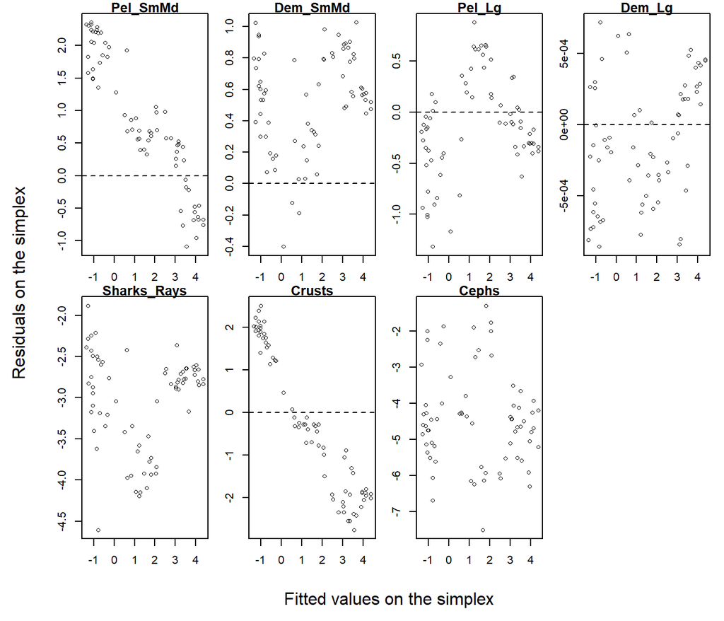

```r
# Fitted values
pred <- modelI$summary.fitted.values$mean[1:(N*(D-1))] %>%
  matrix(., ncol = D - 1, byrow = FALSE)

# Residuals
rsd <- data[, names_alry] - pred

opar <- par(mfrow=c(2, 4),mar=c(2,2,1,1), oma=c(4,4,0,0))
for(i in 1:7){
  plot(pred[, i], rsd[, i], pch = 21,
    main = colnames(rsd)[i], xlab = "Fitted values on the simplex", ylab = "Residuals on the simplex",
    cex = 0.75, lwd = 0.5)
  abline(h = 0, lty = 2)
}
mtext(text=c("Fitted values on the simplex","Residuals on the simplex"), side=c(1,2),at=0.5,line=2,outer=TRUE)
par(opar)
```

#### Simplex

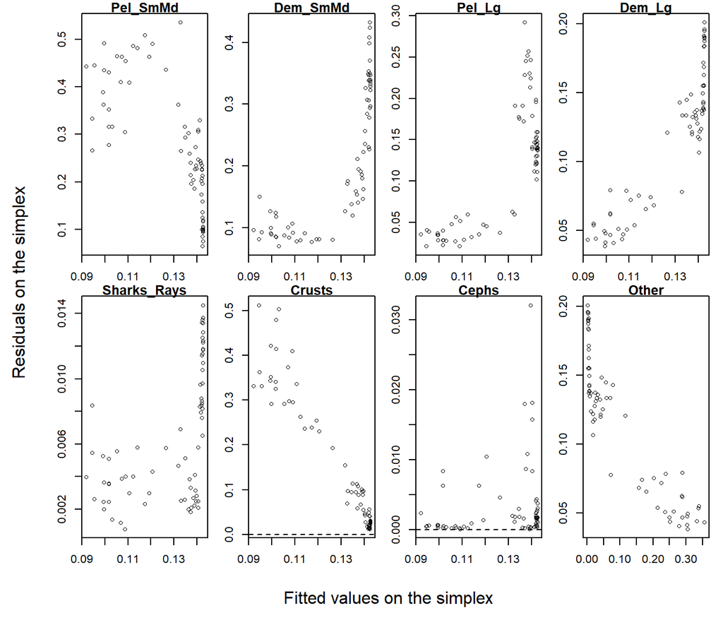

```r
pred <- compositions::alrInv(pred)
colnames(pred) <- names_y
rsd <- compositions::alrInv(rsd)
colnames(rsd) <- names_y

opar <- par(mfrow=c(2, 4),mar=c(2,2,1,1), oma=c(4,4,0,0))
for(i in 1:8){
  plot(pred[, i], rsd[, i], pch = 21,
    main = colnames(rsd)[i], xlab = "Fitted values on the simplex", ylab = "Residuals on the simplex",
    cex = 0.75, lwd = 0.5)
  abline(h = 0, lty = 2)
}
mtext(text=c("Fitted values on the simplex","Residuals on the simplex"), side=c(1,2),at=0.5,line=2,outer=TRUE)
```

```r
par(opar)
```

## Model II

### Fitting the model

Different parameters for each category and time as covariate.

```r
formula_modelII <- resp ~ -1 +
  f(id_intercept, intercept,
    model = "iid",
    initial = log(1/1000),
    fixed = TRUE) +
  f(id_time, time,
    model = "iid",
    initial = log(1/1000),
    fixed = TRUE) +
  f(id_z,
    model = "iid",
    constr = TRUE)

modelII <- inla(
  formula_modelII,
  family = rep("gaussian", D - 1),
  data = inla.stack.data(stk_est),
  control.compute = list(config = TRUE,
                         dic = TRUE,
                         waic = TRUE,
                         cpo = TRUE),
  control.predictor = list(A = inla.stack.A(stk_est),
                           compute = TRUE),
  verbose = FALSE
)
```

### Posterior distribution of the fixed effects

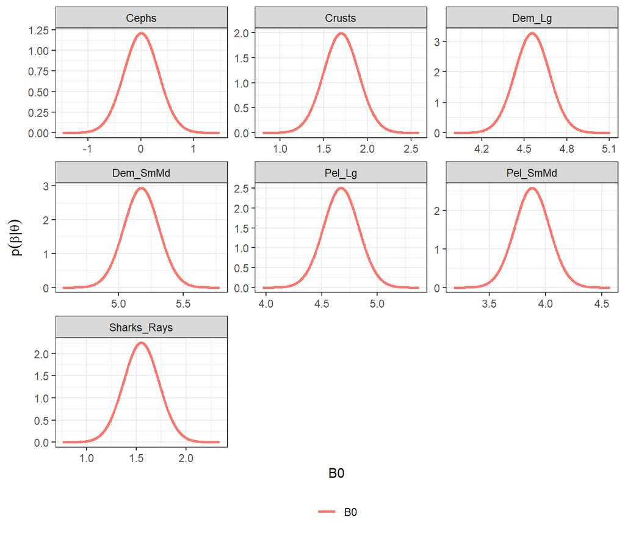

```r
data_beta0 <- rbind(
  data.frame(inla.smarginal(modelII$marginals.random$id_intercept$index.1), alr = names_alry[1], var = "B0"),
  data.frame(inla.smarginal(modelII$marginals.random$id_intercept$index.2), alr = names_alry[2], var = "B0"),
  data.frame(inla.smarginal(modelII$marginals.random$id_intercept$index.3), alr = names_alry[3], var = "B0"),
  data.frame(inla.smarginal(modelII$marginals.random$id_intercept$index.4), alr = names_alry[4], var = "B0"),
  data.frame(inla.smarginal(modelII$marginals.random$id_intercept$index.5), alr = names_alry[5], var = "B0"),
  data.frame(inla.smarginal(modelII$marginals.random$id_intercept$index.6), alr = names_alry[6], var = "B0"),
  data.frame(inla.smarginal(modelII$marginals.random$id_intercept$index.7), alr = names_alry[7], var = "B0")
)

data_beta1 <- rbind(
  data.frame(inla.smarginal(modelII$marginals.random$id_time$index.1), alr = names_alry[1], var = "B1"),
  data.frame(inla.smarginal(modelII$marginals.random$id_time$index.2), alr = names_alry[2], var = "B1"),
  data.frame(inla.smarginal(modelII$marginals.random$id_time$index.3), alr = names_alry[3], var = "B1"),
  data.frame(inla.smarginal(modelII$marginals.random$id_time$index.4), alr = names_alry[4], var = "B1"),
  data.frame(inla.smarginal(modelII$marginals.random$id_time$index.5), alr = names_alry[5], var = "B1"),
  data.frame(inla.smarginal(modelII$marginals.random$id_time$index.6), alr = names_alry[6], var = "B1"),
  data.frame(inla.smarginal(modelII$marginals.random$id_time$index.7), alr = names_alry[7], var = "B1")
)

ggplot() +
  geom_line(data = data_beta0, aes(x = x, y = y, col = var), size = 0.9) +
  facet_wrap(~alr, scales = "free") +
  theme_bw() +
  theme(legend.position = "bottom") +
  xlab("B0") +
  ylab(expression(p(beta *'|'* theta))) +
  theme(legend.title = element_blank())
```

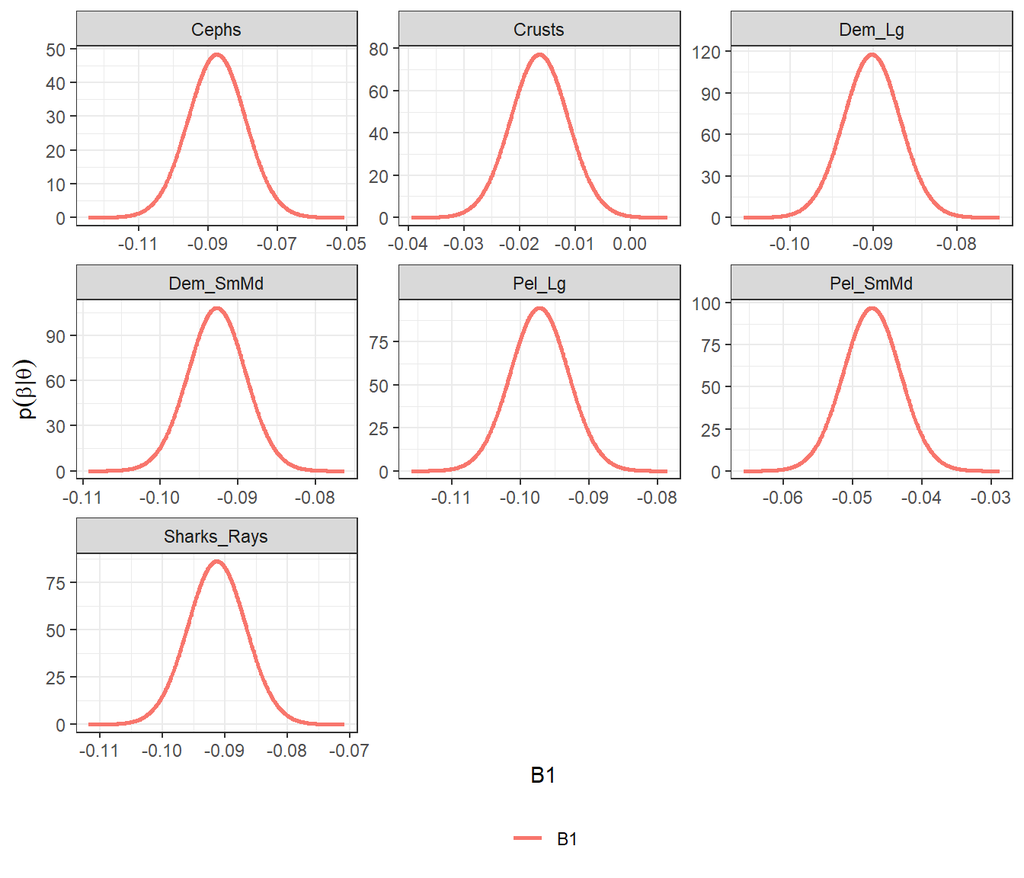

```r
ggplot() +
  geom_line(data = data_beta1, aes(x = x, y = y, col = var), size = 0.9) +
  facet_wrap(~alr, scales = "free") +
  theme_bw() +
  theme(legend.position = "bottom") +
  xlab("B1") +
  ylab(expression(p(beta *'|'* theta))) +
  theme(legend.title = element_blank())
```

### Posterior distribution of the hyperparameters

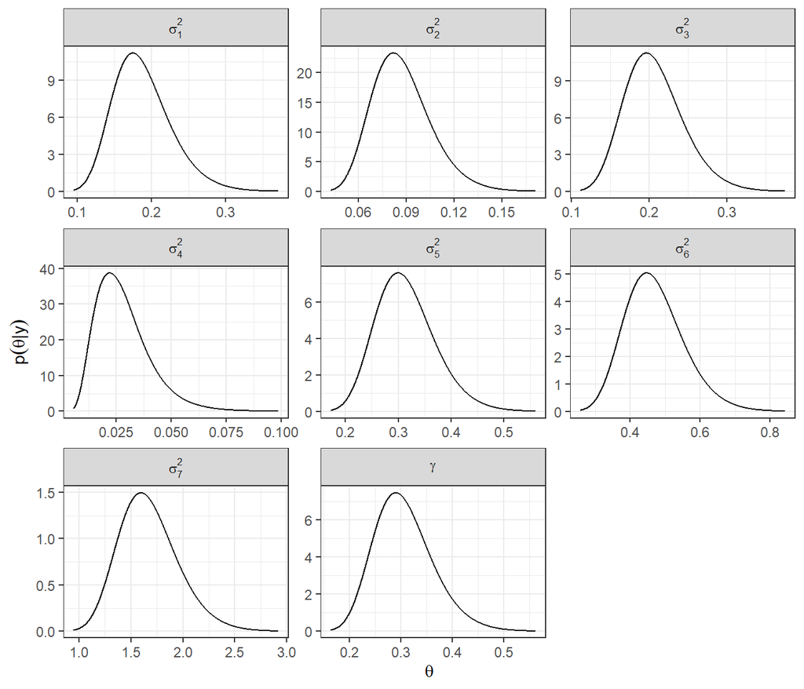

```r
prec <- list(sigma2.1 = modelII$marginals.hyperpar$`Precision for the Gaussian observations`,
             sigma2.2 = modelII$marginals.hyperpar$`Precision for the Gaussian observations[2]`,
             sigma2.3 = modelII$marginals.hyperpar$`Precision for the Gaussian observations[3]`,
             sigma2.4 = modelII$marginals.hyperpar$`Precision for the Gaussian observations[4]`,
             sigma2.5 = modelII$marginals.hyperpar$`Precision for the Gaussian observations[5]`,
             sigma2.6 = modelII$marginals.hyperpar$`Precision for the Gaussian observations[6]`,
             sigma2.7 = modelII$marginals.hyperpar$`Precision for the Gaussian observations[7]`,
             gamma = modelII$marginals.hyper$`Precision for id_z`)

hyper <- lapply(1:length(prec),
                function(x){
                  inla.smarginal(inla.tmarginal(prec[[x]], fun = function(y)(1/y))) %>%
                    data.frame(.)
                })
names(hyper) <- names(prec)

hyper.df <- lapply(1:length(hyper),
                   function(x){
                     cbind(data.frame(hyper[[x]]), name1 = names(hyper)[x])
                   })  %>%
  do.call(rbind.data.frame, .)

hyper.df$name1 <- ordered(hyper.df$name1,
                          levels = c("sigma2.1", "sigma2.2", "sigma2.3", "sigma2.4", "sigma2.5", "sigma2.6", "sigma2.7",
                                     "gamma"))

hyper.df$name1 <- ordered(hyper.df$name1,
                          levels = c("sigma2.1", "sigma2.2", "sigma2.3", "sigma2.4", "sigma2.5", "sigma2.6", "sigma2.7", "gamma"),
                          labels = c("sigma[1]^2", "sigma[2]^2", "sigma[3]^2", "sigma[4]^2", "sigma[5]^2", "sigma[6]^2", "sigma[7]^2", "gamma"))

ggplot(hyper.df) +
  geom_line(aes(x = x, y = y)) +
  facet_wrap(~ name1, scales = "free", labeller = label_parsed) +
  theme_bw() +
  xlab(expression(theta)) +
  ylab(expression(p(theta*'|'*y)))
```

### Fitted values and residuals

#### alr-coordinates

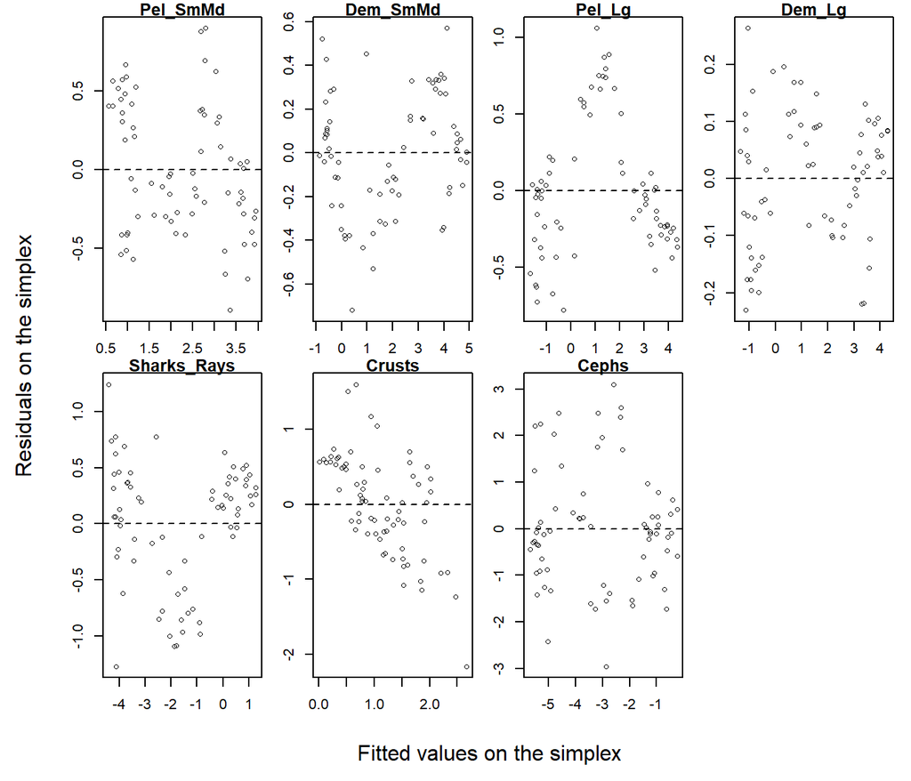

```r
# Fitted values
pred <- modelII$summary.fitted.values$mean[1:(N*(D-1))] %>%
  matrix(., ncol = D - 1, byrow = FALSE)

# Residuals
rsd <- data[, names_alry] - pred

opar <- par(mfrow=c(2, 4),mar=c(2,2,1,1), oma=c(4,4,0,0))
for(i in 1:7){
  plot(pred[, i], rsd[, i], pch = 21,
    main = colnames(rsd)[i], xlab = "Fitted values on the simplex", ylab = "Residuals on the simplex",
    cex = 0.75, lwd = 0.5)
  abline(h = 0, lty = 2)
}
mtext(text=c("Fitted values on the simplex","Residuals on the simplex"), side=c(1,2),at=0.5,line=2,outer=TRUE)
par(opar)
```

#### Simplex

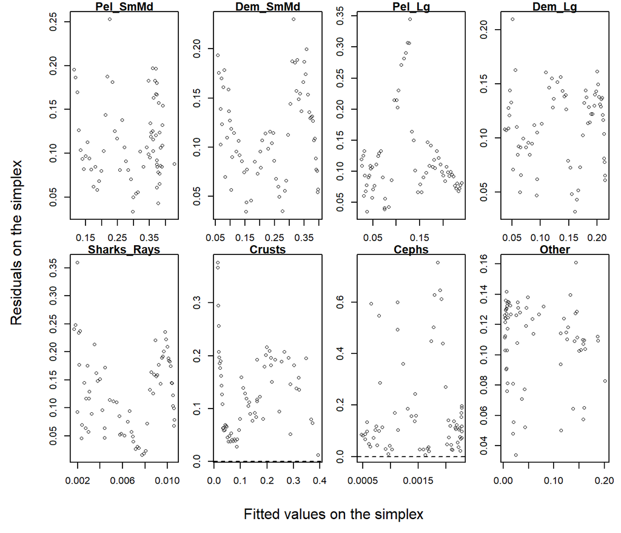

```r
pred <- compositions::alrInv(pred)
colnames(pred) <- names_y
rsd <- compositions::alrInv(rsd)
colnames(rsd) <- names_y

opar <- par(mfrow=c(2, 4),mar=c(2,2,1,1), oma=c(4,4,0,0))
for(i in 1:8){
  plot(pred[, i], rsd[, i], pch = 21,
    main = colnames(rsd)[i], xlab = "Fitted values on the simplex", ylab = "Residuals on the simplex",
    cex = 0.75, lwd = 0.5)
  abline(h = 0, lty = 2)
}
mtext(text=c("Fitted values on the simplex","Residuals on the simplex"), side=c(1,2),at=0.5,line=2,outer=TRUE)
```

```r
par(opar)
```

## Model III

### Fitting the model

Different parameters for intercept and same temporal effect RW1.

```r
formula_modelIII <- resp ~ -1 +
  f(id_intercept, intercept,
    model = "iid",
    initial = log(1/1000),
    fixed = TRUE) +
  f(Pel_SmMd, model = "rw1") +
  f(Dem_SmMd, copy = "Pel_SmMd",
    fixed = TRUE) +
  f(Pel_Lg, copy = "Pel_SmMd",
    fixed = TRUE) +
  f(Dem_Lg, copy = "Pel_SmMd",
    fixed = TRUE) +
  f(Sharks_Rays, copy = "Pel_SmMd",
    fixed = TRUE) +
  f(Crusts, copy = "Pel_SmMd",
    fixed = TRUE) +
  f(Cephs, copy = "Pel_SmMd",
    fixed = TRUE) +
  f(id_z,
    model = "iid",
    constr = TRUE)

modelIII <- inla(
  formula_modelIII,
  family = rep("gaussian", D - 1),
  data = inla.stack.data(stk_est),
  control.compute = list(config = TRUE,
                         dic = TRUE,
                         waic = TRUE,
                         cpo = TRUE),
  control.predictor = list(A = inla.stack.A(stk_est),
                           compute = TRUE),
  verbose = FALSE
)
```

### Fitted values and residuals

#### alr-coordinates

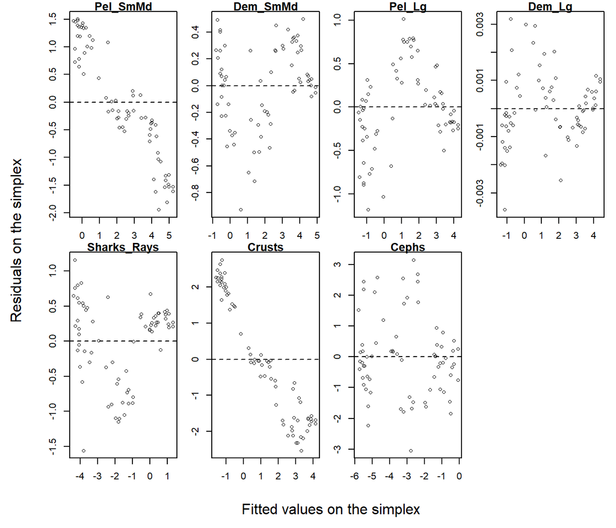

```r
# Fitted values
pred <- modelIII$summary.fitted.values$mean[1:(N*(D-1))] %>%
  matrix(., ncol = D - 1, byrow = FALSE)

# Residuals
rsd <- data[, names_alry] - pred

opar <- par(mfrow=c(2, 4),mar=c(2,2,1,1), oma=c(4,4,0,0))
for(i in 1:7){
  plot(pred[, i], rsd[, i], pch = 21,
    main = colnames(rsd)[i], xlab = "Fitted values on the simplex", ylab = "Residuals on the simplex",
    cex = 0.75, lwd = 0.5)
  abline(h = 0, lty = 2)
}
mtext(text=c("Fitted values on the simplex","Residuals on the simplex"), side=c(1,2),at=0.5,line=2,outer=TRUE)
par(opar)
```

#### Simplex

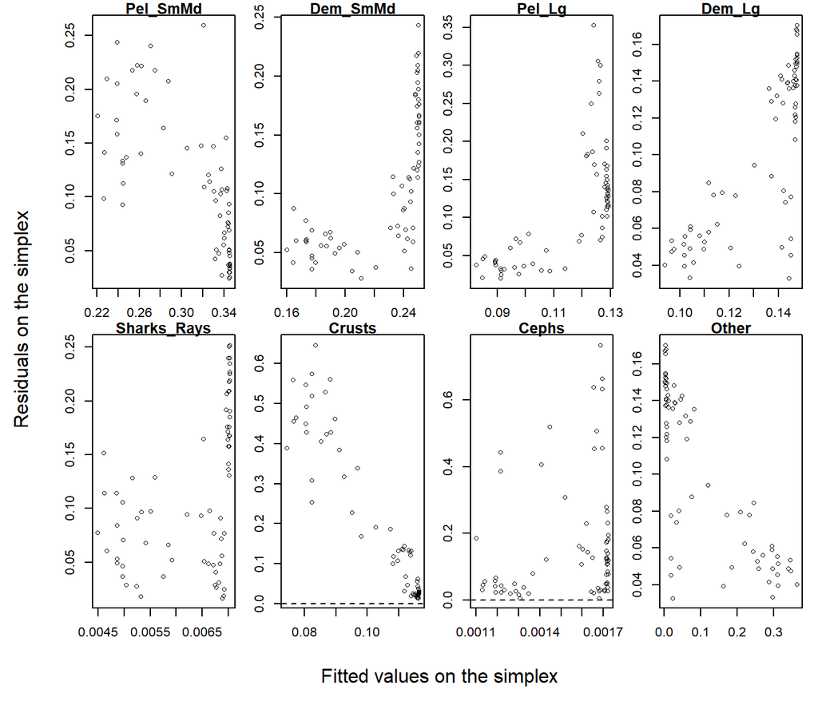

```r
pred <- compositions::alrInv(pred)
colnames(pred) <- names_y
rsd <- compositions::alrInv(rsd)
colnames(rsd) <- names_y

opar <- par(mfrow=c(2, 4),mar=c(2,2,1,1), oma=c(4,4,0,0))
for(i in 1:8){
  plot(pred[, i], rsd[, i], pch = 21,
    main = colnames(rsd)[i], xlab = "Fitted values on the simplex", ylab = "Residuals on the simplex",
    cex = 0.75, lwd = 0.5)
  abline(h = 0, lty = 2)
}
mtext(text=c("Fitted values on the simplex","Residuals on the simplex"), side=c(1,2),at=0.5,line=2,outer=TRUE)
```

```r
par(opar)
```

## Model IV

### Fitting the model

Different parameters for fixed effects, and different realizations of the temporal effect for each linear predictor RW1.

```r
formula_modelIV <- resp ~ -1 +
  f(id_intercept, intercept,
    model = "iid",
    initial = log(1/1000),
    fixed = TRUE) +
  f(i,
    model = "rw1",
    replicate = i.repl) +
  f(id_z,
    model = "iid",
    constr = TRUE)

modelIV <- inla(
  formula_modelIV,
  family = rep("gaussian", D - 1),
  data = inla.stack.data(stk_est),
  control.compute = list(config = TRUE,
                         dic = TRUE,
                         waic = TRUE,
                         cpo = TRUE),
  control.predictor = list(A = inla.stack.A(stk_est),
                           compute = TRUE),
  verbose = FALSE
)
```

### Fitted values and residuals

#### alr-coordinates

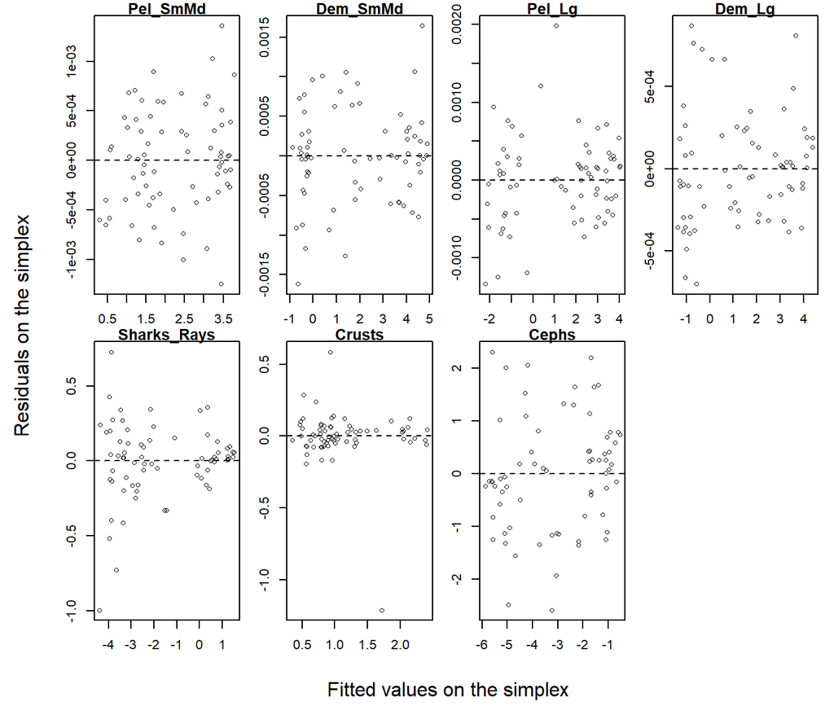

```r
# Fitted values
pred <- modelIV$summary.fitted.values$mean[1:(N*(D-1))] %>%
  matrix(., ncol = D - 1, byrow = FALSE)

# Residuals
rsd <- data[, names_alry] - pred

opar <- par(mfrow=c(2, 4),mar=c(2,2,1,1), oma=c(4,4,0,0))
for(i in 1:7){
  plot(pred[, i], rsd[, i], pch = 21,
    main = colnames(rsd)[i], xlab = "Fitted values on the simplex", ylab = "Residuals on the simplex",
    cex = 0.75, lwd = 0.5)
  abline(h = 0, lty = 2)
}
mtext(text=c("Fitted values on the simplex","Residuals on the simplex"), side=c(1,2),at=0.5,line=2,outer=TRUE)
par(opar)
```

#### Simplex

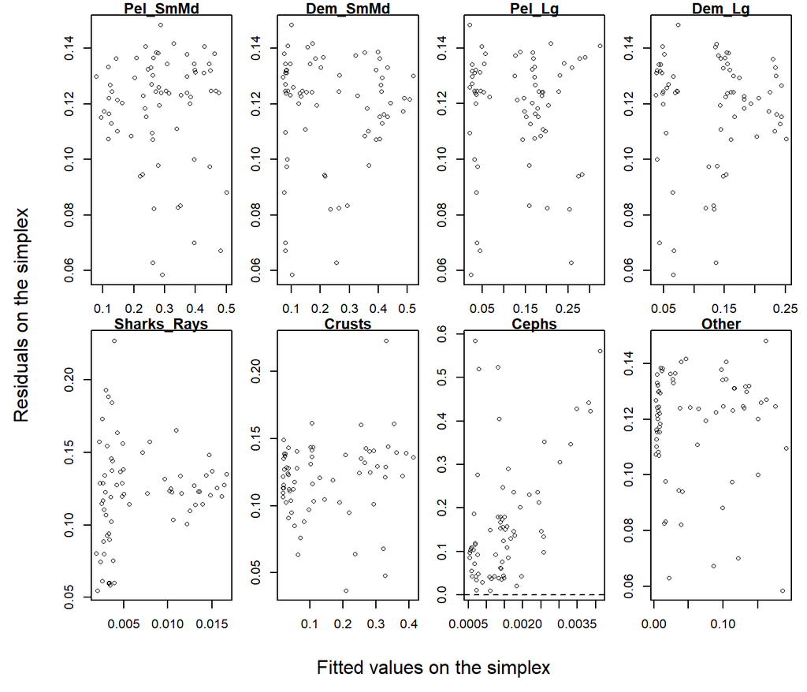

```r
pred <- compositions::alrInv(pred)
colnames(pred) <- names_y
rsd <- compositions::alrInv(rsd)
colnames(rsd) <- names_y

opar <- par(mfrow=c(2, 4),mar=c(2,2,1,1), oma=c(4,4,0,0))
for(i in 1:8){
  plot(pred[, i], rsd[, i], pch = 21,
    main = colnames(rsd)[i], xlab = "Fitted values on the simplex", ylab = "Residuals on the simplex",
    cex = 0.75, lwd = 0.5)
  abline(h = 0, lty = 2)
}
mtext(text=c("Fitted values on the simplex","Residuals on the simplex"), side=c(1,2),at=0.5,line=2,outer=TRUE)
```

```r
par(opar)
```

## Model V

### Fitting the model

Different parameters for intercept and same temporal effect AR(1).

```r
formula_modelV <- resp ~ -1 +
  f(id_intercept, intercept,
    model = "iid",
    initial = log(1/1000),
    fixed = TRUE) +
  f(Pel_SmMd, model = "ar1") +
  f(Dem_SmMd, copy = "Pel_SmMd",
    fixed = TRUE) +
  f(Pel_Lg, copy = "Pel_SmMd",
    fixed = TRUE) +
  f(Dem_Lg, copy = "Pel_SmMd",
    fixed = TRUE) +
  f(Sharks_Rays, copy = "Pel_SmMd",
    fixed = TRUE) +
  f(Crusts, copy = "Pel_SmMd",
    fixed = TRUE) +
  f(Cephs, copy = "Pel_SmMd",
    fixed = TRUE) +
  f(id_z,
    model = "iid",
    constr = TRUE)

modelV <- inla(
  formula_modelV,
  family = rep("gaussian", D - 1),
  data = inla.stack.data(stk_est),
  control.compute = list(config = TRUE,
                         dic = TRUE,
                         waic = TRUE,
                         cpo = TRUE),
  control.predictor = list(A = inla.stack.A(stk_est),
                           compute = TRUE),
  verbose = FALSE
)
```

### Fitted values and residuals

#### alr-coordinates

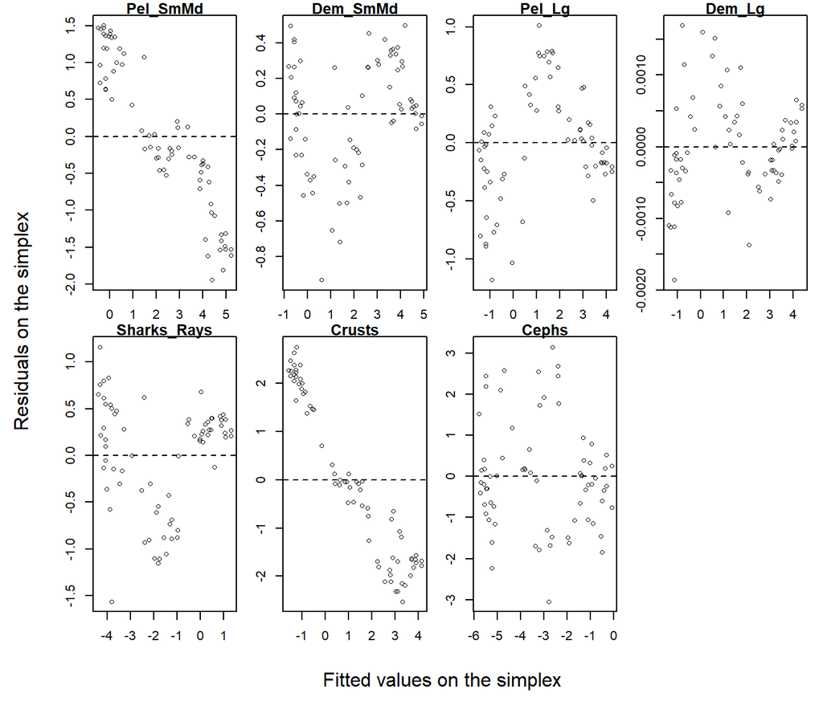

```r
# Fitted values
pred <- modelV$summary.fitted.values$mean[1:(N*(D-1))] %>%
  matrix(., ncol = D - 1, byrow = FALSE)

# Residuals
rsd <- data[, names_alry] - pred

opar <- par(mfrow=c(2, 4),mar=c(2,2,1,1), oma=c(4,4,0,0))
for(i in 1:7){
  plot(pred[, i], rsd[, i], pch = 21,
    main = colnames(rsd)[i], xlab = "Fitted values on the simplex", ylab = "Residuals on the simplex",
    cex = 0.75, lwd = 0.5)
  abline(h = 0, lty = 2)
}
mtext(text=c("Fitted values on the simplex","Residuals on the simplex"), side=c(1,2),at=0.5,line=2,outer=TRUE)
par(opar)
```

#### Simplex

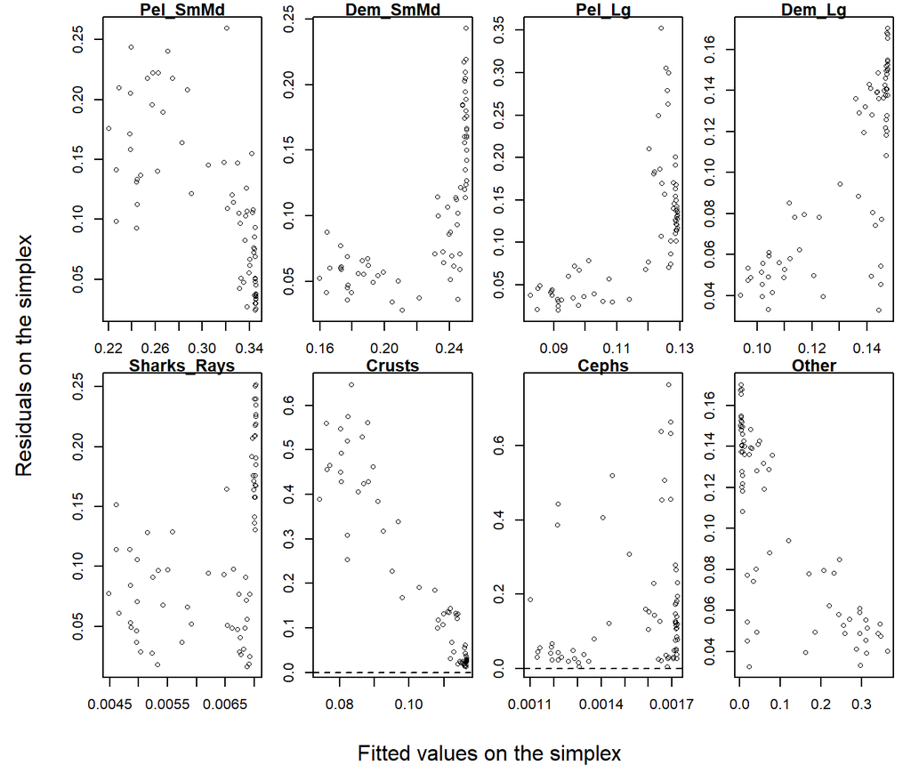

```r
pred <- compositions::alrInv(pred)
colnames(pred) <- names_y
rsd <- compositions::alrInv(rsd)
colnames(rsd) <- names_y

opar <- par(mfrow=c(2, 4),mar=c(2,2,1,1), oma=c(4,4,0,0))
for(i in 1:8){
  plot(pred[, i], rsd[, i], pch = 21,
    main = colnames(rsd)[i], xlab = "Fitted values on the simplex", ylab = "Residuals on the simplex",
    cex = 0.75, lwd = 0.5)
  abline(h = 0, lty = 2)
}
mtext(text=c("Fitted values on the simplex","Residuals on the simplex"), side=c(1,2),at=0.5,line=2,outer=TRUE)
```

```r
par(opar)
```

## Model VI

### Fitting the model

Have different parameters for fixed effects, and different realizations of the temporal effect for each linear predictor AR(1).

```r
formula_modelVI <- resp ~ -1 +
  f(id_intercept, intercept,
    model = "iid",
    initial = log(1/1000),
    fixed = TRUE) +
  f(i,
    model = "ar1",
    replicate = i.repl) +
  f(id_z,
    model = "iid",
    constr = TRUE)

modelVI <- inla(
  formula_modelVI,
  family = rep("gaussian", D - 1),
  data = inla.stack.data(stk_est),
  control.compute = list(config = TRUE,
                         dic = TRUE,
                         waic = TRUE,
                         cpo = TRUE),
  control.predictor = list(A = inla.stack.A(stk_est),
                           compute = TRUE),
  verbose = FALSE
)
```

### Fitted values and residuals

#### alr-coordinates

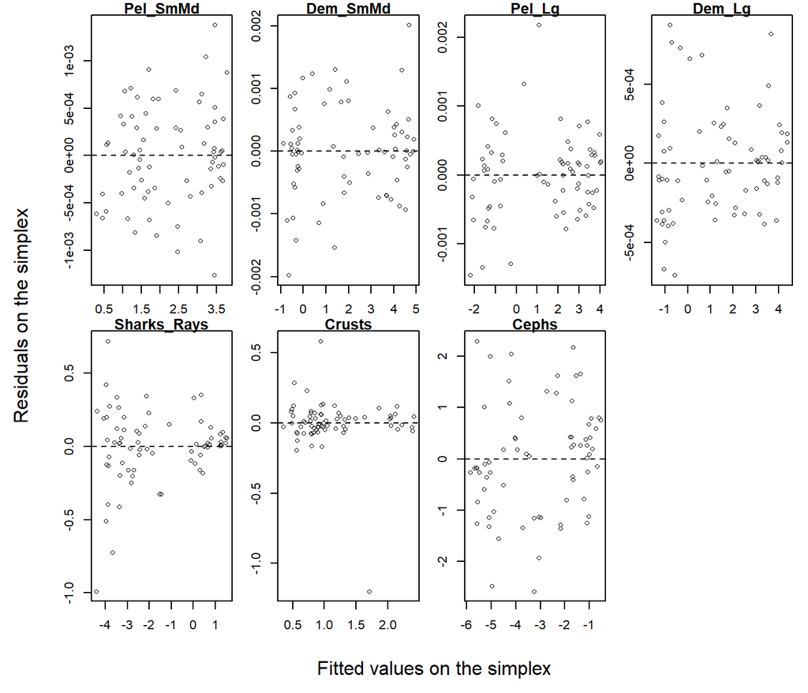

```r
# Fitted values
pred <- modelVI$summary.fitted.values$mean[1:(N*(D-1))] %>%
  matrix(., ncol = D - 1, byrow = FALSE)

# Residuals
rsd <- data[, names_alry] - pred

opar <- par(mfrow=c(2, 4),mar=c(2,2,1,1), oma=c(4,4,0,0))
for(i in 1:7){
  plot(pred[, i], rsd[, i], pch = 21,
    main = colnames(rsd)[i], xlab = "Fitted values on the simplex", ylab = "Residuals on the simplex",
    cex = 0.75, lwd = 0.5)
  abline(h = 0, lty = 2)
}
mtext(text=c("Fitted values on the simplex","Residuals on the simplex"), side=c(1,2),at=0.5,line=2,outer=TRUE)
par(opar)
```

#### Simplex

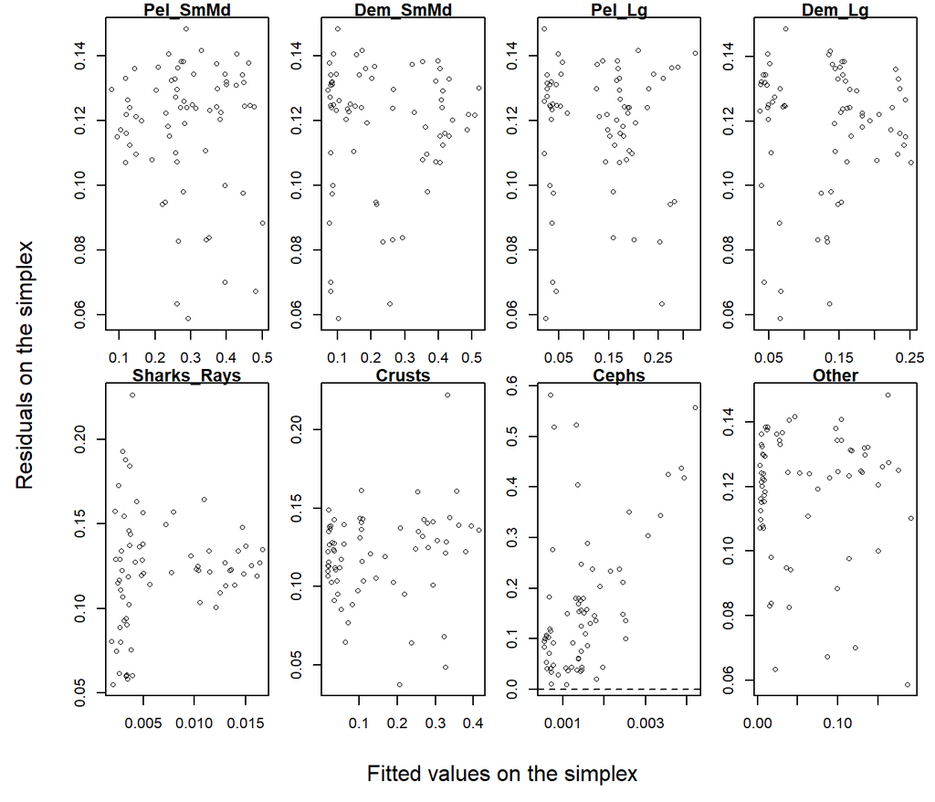

```r
pred <- compositions::alrInv(pred)
colnames(pred) <- names_y
rsd <- compositions::alrInv(rsd)
colnames(rsd) <- names_y

opar <- par(mfrow=c(2, 4),mar=c(2,2,1,1), oma=c(4,4,0,0))
for(i in 1:8){
  plot(pred[, i], rsd[, i], pch = 21,
    main = colnames(rsd)[i], xlab = "Fitted values on the simplex", ylab = "Residuals on the simplex",
    cex = 0.75, lwd = 0.5)
  abline(h = 0, lty = 2)
}
mtext(text=c("Fitted values on the simplex","Residuals on the simplex"), side=c(1,2),at=0.5,line=2,outer=TRUE)
```

```r
par(opar)
```

## Model VII

### Fitting the model

```r
formula_modelVII <- resp ~ -1 +
  f(id_intercept, intercept,
    model = "iid",
    initial = log(1/1000),
    fixed = TRUE) +
  f(i,
    model = "rw2",
    replicate = i.repl) +
  f(id_z,
    model = "iid",
    constr = TRUE)

modelVII <- inla(
  formula_modelVII,
  family = rep("gaussian", D - 1),
  data = inla.stack.data(stk_est),
  control.compute = list(config = TRUE,
                         dic = TRUE,
                         waic = TRUE,
                         cpo = TRUE),
  control.predictor = list(A = inla.stack.A(stk_est),
                           compute = TRUE),
  verbose = FALSE
)
```

### Fitted values and residuals

#### alr-coordinates

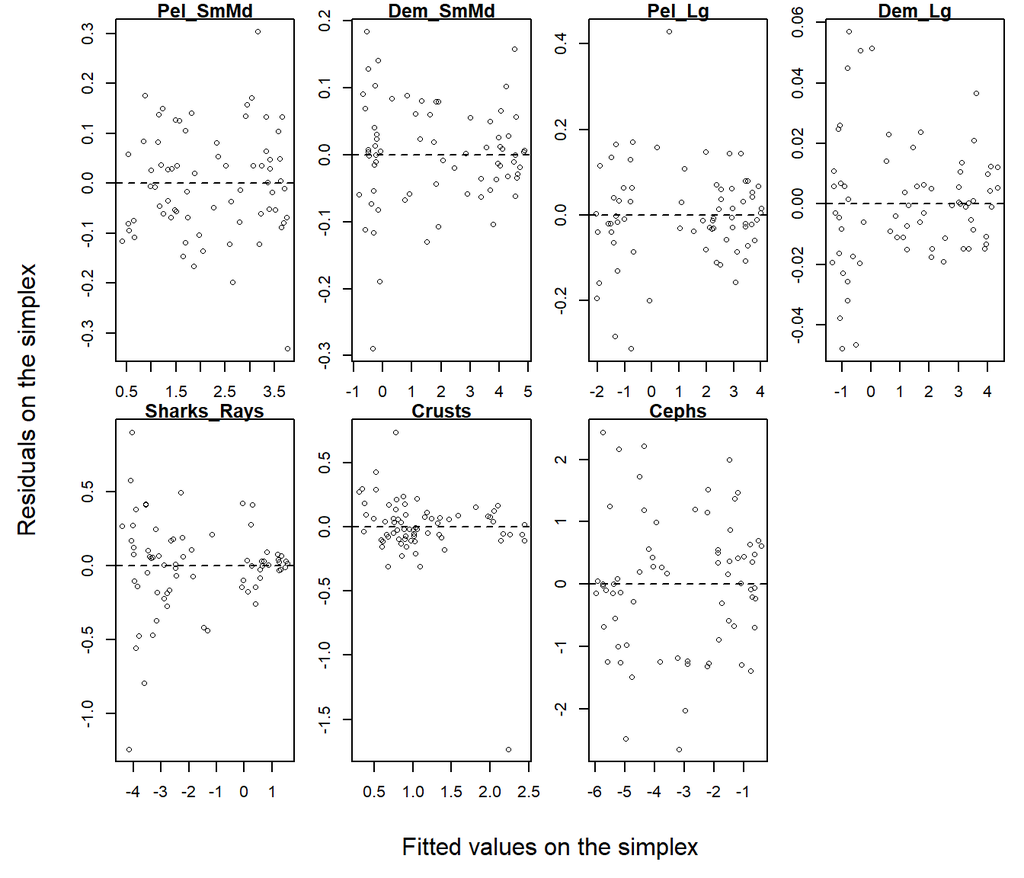

```r
# Fitted values
pred <- modelVII$summary.fitted.values$mean[1:(N*(D-1))] %>%
  matrix(., ncol = D - 1, byrow = FALSE)

# Residuals
rsd <- data[, names_alry] - pred

#pdf(file = "alr_residuals_RW2_scotian_shelf.pdf", width = 7, height = 4)
opar <- par(mfrow=c(2, 4),mar=c(2,2,1,1), oma=c(4,4,0,0))
for(i in 1:7){
  plot(pred[, i], rsd[, i], pch = 21,
    main = colnames(rsd)[i], xlab = "Fitted values", ylab = "Residuals",
    cex = 0.75, lwd = 0.5)
  abline(h = 0, lty = 2)
}
mtext(text=c("Fitted values on the simplex","Residuals on the simplex"), side=c(1,2),at=0.5,line=2,outer=TRUE)
par(opar)
```

```r
#dev.off()
```

#### Simplex

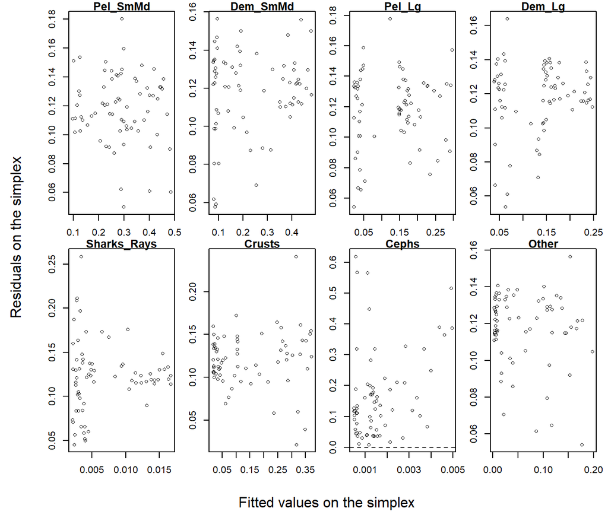

```r
pred <- compositions::alrInv(pred)
colnames(pred) <- names_y
rsd <- compositions::alrInv(rsd)
colnames(rsd) <- names_y

opar <- par(mfrow=c(2, 4),mar=c(2,2,1,1), oma=c(4,4,0,0))
for(i in 1:8){
  plot(pred[, i], rsd[, i], pch = 21,
    main = colnames(rsd)[i], xlab = "Fitted values on the simplex", ylab = "Residuals on the simplex",
    cex = 0.75, lwd = 0.5)
  abline(h = 0, lty = 2)
}
mtext(text=c("Fitted values on the simplex","Residuals on the simplex"), side=c(1,2),at=0.5,line=2,outer=TRUE)
```

```r
par(opar)
```

# Compare models

```r
model_list <- list(modelI, modelII, modelIII, modelIV, modelV, modelVI, modelVII)
names(model_list) <- paste0("model", 1:length(model_list))

measures <- lapply(model_list, function(mod){
  xx <- inla.posterior.sample(1000, mod, seed = inla.seed)
  inf <- parallel::mclapply(xx, INLAcomp::extract_lp_sigma)

  # DIC
  dic_mod <- INLAcomp::dic.mult(inf, y = data[, names_alry])

  #WAIc
  waic_mod <- INLAcomp::waic.mult(inf, y = data[, names_alry])

  #lIST FOR cpo
  friends_list <- 1:(N*(D-1)) %>%
  lapply(., function(x){
    c(seq(x, N*(D-1), by = N)[-1],
      rev(seq(x, 1, by = -N))) -> res
    res[order(res)]
  })


  a4 <- INLA::inla.group.cv(result = mod,
                          num.level.sets = -1,
                          strategy = "posterior",
                          friends = friends_list,
                          verbose = FALSE)

  LCPO <- a4$cv %>% log(.) %>% mean(.) %>% -.

  data.frame(DIC = dic_mod, WAIC = waic_mod, LCPO = LCPO)
})

measures <-  as.data.frame(do.call(rbind, measures))

measures[, c("DIC.dic", "WAIC.waic", "LCPO")]
```

|  | DIC.dic | WAIC.waic | LCPO |
| --- | --- | --- | --- |
| model1 | 1650.8674 | 1648.9426 | 1.78694604 |
| model2 | 889.9366 | 892.7886 | 0.75029347 |
| model3 | 582.9725 | 661.5539 | 0.60617076 |
| model4 | -913.1052 | -729.3564 | 0.06870201 |
| model5 | 597.6380 | 639.7503 | 0.60609473 |
| model6 | -810.3685 | -718.4568 | 0.06971441 |
| model7 | 219.8456 | 253.6584 | -0.03323199 |

# RW1 and AR(1) overfitting

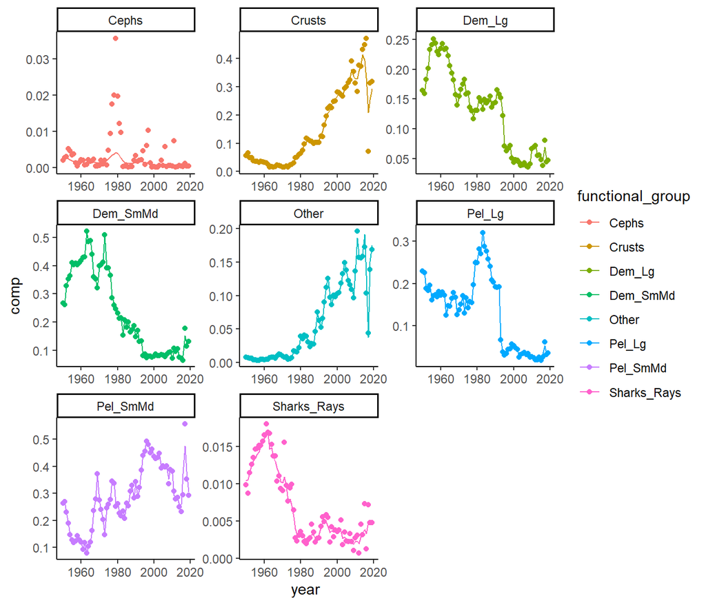

```r
# Fitted values
pred <- modelIV$summary.fitted.values$mean[1:(N*(D-1))] %>%
  matrix(., ncol = D - 1, byrow = FALSE)
pred <- compositions::alrInv(pred)
colnames(pred) <- names_y
```

# RW2 smoother solution

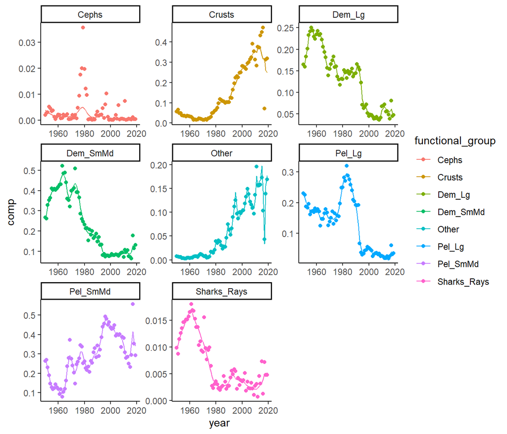

```r
# Fitted values
pred <- modelVII$summary.fitted.values$mean[1:(N*(D-1))] %>%
  matrix(., ncol = D - 1, byrow = FALSE)
pred <- compositions::alrInv(pred)
colnames(pred) <- names_y
```

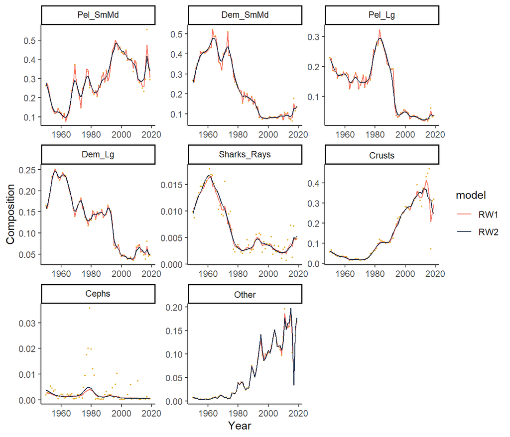

```r
fitted_rw1$model <- "RW1"
fitted_rw2$model <- "RW2"
fitted <- rbind(fitted_rw1, fitted_rw2)

p <- ggplot() +
  geom_point(data = observed, aes(y = comp, x = year), color = "#e6af2e", size = 0.4) +
  geom_line(data = fitted, aes(y = comp, x = year, color = model), linewidth = 0.4) +
  scale_color_manual(values = c("RW1" = "#f87060", "RW2" = "#102542")) +
  facet_wrap(~ factor(functional_group, levels = func_grp_lvls), scales = "free",
             labeller = label_parsed) +
  xlab("Year") +
  ylab("Composition") +
  theme_classic()

#ggsave(filename = "img/scotian_shelf_rw1_rw2_fit.pdf", p, height = 4, width = 8)
print(p)
```

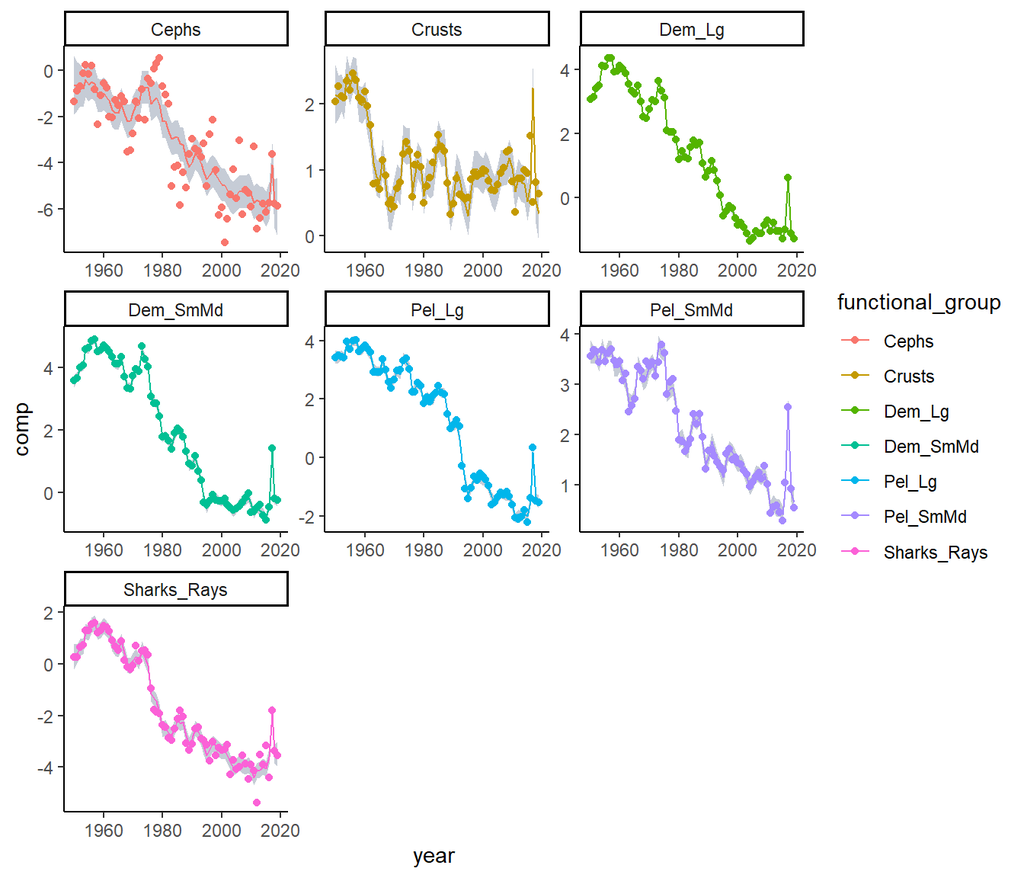

```r
pred <- modelVII$summary.fitted.values$mean[1:(N*(D-1))] %>%
  matrix(., ncol = D - 1, byrow = FALSE)
colnames(pred) <- names_alry

q25 <- modelVII$summary.fitted.values$`0.025quant`[1:(N*(D-1))] %>%
  matrix(., ncol = D - 1, byrow = FALSE)
colnames(q25) <- names_alry
q975 <- modelVII$summary.fitted.values$`0.975quant`[1:(N*(D-1))] %>%
  matrix(., ncol = D - 1, byrow = FALSE)
colnames(q975) <- names_alry

fitted_rw2 <- data.frame(pred) %>%
  mutate(year = single_lme$year) %>%
  pivot_longer(!year, values_to = "comp", names_to = "functional_group")

q25 <- data.frame(q25) %>%
  mutate(year = single_lme$year) %>%
  pivot_longer(!year, values_to = "q25", names_to = "functional_group")

q975 <- data.frame(q975) %>%
  mutate(year = single_lme$year) %>%
  pivot_longer(!year, values_to = "q975", names_to = "functional_group")
q <- full_join(q25, q975, by = c("year", "functional_group"))

observed <- data %>%
  pivot_longer(!time, values_to = "comp", names_to = "functional_group")

ggplot() +
  geom_ribbon(data = q, aes(x = year, ymin = q25, ymax = q975), fill = "#8d99ae", alpha = 0.5) +
  geom_line(data = fitted_rw2, aes(y = comp, x = year, color = functional_group)) +
  geom_point(data = observed, aes(y = comp, x = (time + 1949), color = functional_group)) +
  facet_wrap(~ functional_group, scales = "free") +
  theme_classic()
```

### Fixed effects

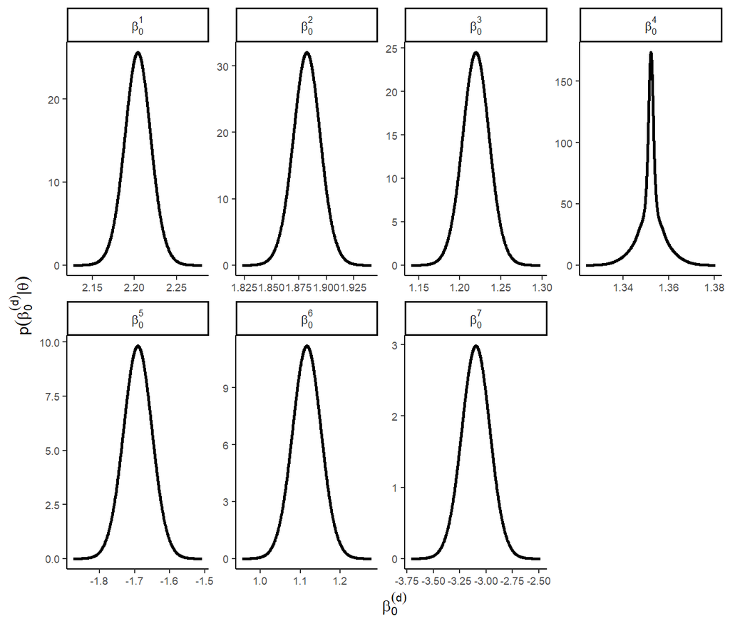

```r
beta0 <- lapply(1:(D-1), function(i) inla.smarginal(modelVII$marginals.random$id_intercept[[i]]))
names(beta0) <- as.character(1:7)

beta0_df <- lapply(1:length(beta0),
                   function(i){
                     cbind(data.frame(beta0[[i]]), name1 = names(beta0)[i])
                   })  %>%
  do.call(rbind.data.frame, .)

p <- ggplot() +
  geom_line(data = beta0_df, aes(x = x, y = y), size = 1) +
  theme_classic() +
  theme(legend.position = "bottom") +
  facet_wrap(~ name1, nrow = 2, scales = "free",
               labeller = label_bquote(beta [0] ^ .(name1))) +
  xlab(expression(beta[0]^(d))) +
  ylab(expression(p(beta[0]^(d) *'|'* theta))) +
  theme(legend.title = element_blank(),
        axis.text = element_text(size = 7))

#ggsave("img/scotian_shelf_posterior_intercept.pdf", p, height = 4, width = 7)
print(p)
```

### Hyperparameters

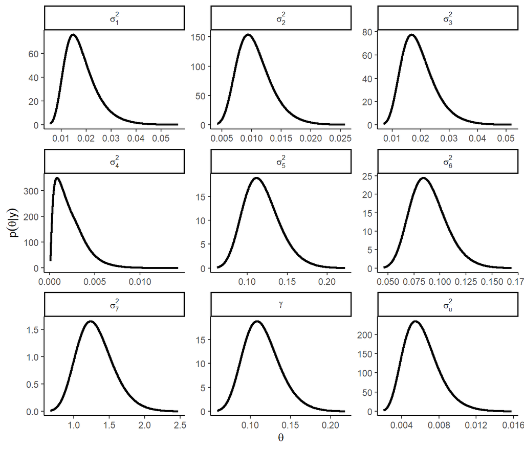

```r
prec <- modelVII$marginals.hyperpar[1:(D-1)] %>%
  c(., list(modelVII$marginals.hyperpar$`Precision for id_z`), list(modelVII$marginals.hyperpar$`Precision for i`))

hyper <- lapply(1:length(prec),
                function(x){
                  inla.smarginal(inla.tmarginal(prec[[x]], fun = function(y)(1/y))) %>%
                    data.frame(.)
                })
names(hyper) <- c(paste0("sigma2.", 1:(D-1)), "gamma", "sigma_u")

hyper.df <- lapply(1:length(hyper),
                   function(x){
                     cbind(data.frame(hyper[[x]]), name1 = names(hyper)[x])
                   })  %>%
  do.call(rbind.data.frame, .)


hyper.df$name1 <- ordered(hyper.df$name1,
                          levels = c("sigma2.1", "sigma2.2", "sigma2.3", "sigma2.4", "sigma2.5", "sigma2.6", "sigma2.7",
                                     "gamma", "sigma_u"),
                          labels = c("sigma[1]^2", "sigma[2]^2", "sigma[3]^2", "sigma[4]^2", "sigma[5]^2", "sigma[6]^2", "sigma[7]^2", "gamma", "sigma[u]^2"))

p <- ggplot(hyper.df) +
  geom_line(aes(x = x, y = y), size = 1) +
  facet_wrap(~ name1, scales = "free",
             labeller = label_parsed) +
  theme_classic() +
  xlab(expression(theta)) +
  ylab(expression(p(theta*'|'*y)))

#ggsave("img/scotian_shelf_posterior_hyperparam.pdf", p, height = 4, width = 7)
print(p)
```